# Kirill Burin - 923357830

# Data Analysis of the Penguin Dataset

## Abstract

This report determines which characteristics in the dataset are effective for distinguishing between species of penguins, like Adelie, Chinstrap, and Gentoo. Rather than focusing only on prediction accuracy, I study how much information each variable carries about species identity. For each candidate variable, I examine its distribution, define bins using hierarchical clustering, construct species-by-bin contingency tables, and compute entropy-based separation measures. This allows me to compare variables by how much uncertainty about species they remove and to identify which measurements are most biologically informative.

## Introduction

In the paper "Ecological Sexual Dimorphism and Environmental Variability within a Community of Antarctic Penguins (Genus Pygoscelis)," authors discuss sexual dimorphism and foraging behavior of the penguins before their reproductive period. The dataset in the paper "Penguins" is related to the penguins living in the vicinity of Palmer Station, Antarctica. The dataset was collected by Dr. Kristen Gorman and Palmer Station LTER. In the penguins dataset, the features include bill length, bill depth, flipper length, body mass, sex, and island where the penguins reside.

It becomes really interesting when one tries to understand the difference between penguins because there are three kinds of penguins such as Adelie, Chinstrap, and Gentoo. These penguins have very similar appearances but still differ in their body measurements. However, not all body measurements are valuable. Thus, the main research question is whether it is possible to differentiate these penguin species based on their body measurements.

## Overview of the Data

```python
import numpy as np
import pandas as pd
import matplotlib.pyplot as plt
import seaborn as sns
from itertools import combinations
from scipy.cluster.hierarchy import linkage, dendrogram, fcluster
from sklearn.preprocessing import StandardScaler
df = pd.read_csv("penguins.csv")
df = df.dropna()
df.head()
```

|  | species | island | bill_length_mm | bill_depth_mm | flipper_length_mm | body_mass_g | sex | year |
| --- | --- | --- | --- | --- | --- | --- | --- | --- |
| 0 | Adelie | Torgersen | 39.1 | 18.7 | 181.0 | 3750.0 | male | 2007 |
| 1 | Adelie | Torgersen | 39.5 | 17.4 | 186.0 | 3800.0 | female | 2007 |
| 2 | Adelie | Torgersen | 40.3 | 18.0 | 195.0 | 3250.0 | female | 2007 |
| 4 | Adelie | Torgersen | 36.7 | 19.3 | 193.0 | 3450.0 | female | 2007 |
| 5 | Adelie | Torgersen | 39.3 | 20.6 | 190.0 | 3650.0 | male | 2007 |

```python
species_count = df["species"].value_counts()

for sp in df["species"].unique():
    male_n = df.loc[(df["sex"] == "male") & (df["species"] == sp)].shape[0]
    female_n = df.loc[(df["sex"] == "female") & (df["species"] == sp)].shape[0]
    print(f"There are {male_n} male {sp} penguins and {female_n} female {sp} penguins.")
print("In this Dataset we see  3 penguisn scattered along 3 island Torgersen, Biscoe, Dream. Total speices is 333, 146 of Adelie, 119 of Gentoo, and 68 of Chinstrap. There is 168 males and 165 females. ")
df[["bill_length_mm","bill_depth_mm","flipper_length_mm","body_mass_g"]].describe()
```

```
There are 73 male Adelie penguins and 73 female Adelie penguins.
There are 61 male Gentoo penguins and 58 female Gentoo penguins.
There are 34 male Chinstrap penguins and 34 female Chinstrap penguins.
In this Dataset we see  3 penguisn scattered along 3 island Torgersen, Biscoe, Dream. Total speices is 333, 146 of Adelie, 119 of Gentoo, and 68 of Chinstrap. There is 168 males and 165 females.
```

|  | bill_length_mm | bill_depth_mm | flipper_length_mm | body_mass_g |
| --- | --- | --- | --- | --- |
| count | 333.000000 | 333.000000 | 333.000000 | 333.000000 |
| mean | 43.992793 | 17.164865 | 200.966967 | 4207.057057 |
| std | 5.468668 | 1.969235 | 14.015765 | 805.215802 |
| min | 32.100000 | 13.100000 | 172.000000 | 2700.000000 |
| 25% | 39.500000 | 15.600000 | 190.000000 | 3550.000000 |
| 50% | 44.500000 | 17.300000 | 197.000000 | 4050.000000 |
| 75% | 48.600000 | 18.700000 | 213.000000 | 4775.000000 |
| max | 59.600000 | 21.500000 | 231.000000 | 6300.000000 |

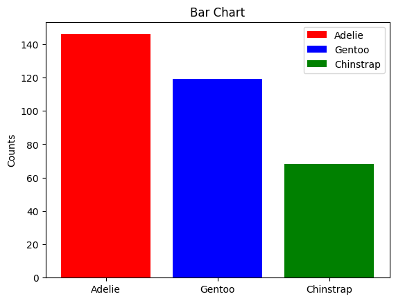

```python
plt.figure()
plt.bar(species_count.index, species_count.values, color = ["red","blue","green"], label = ["Adelie","Gentoo","Chinstrap"])
plt.legend()
plt.ylabel("Counts")
plt.title("Bar Chart")
plt.show()
```

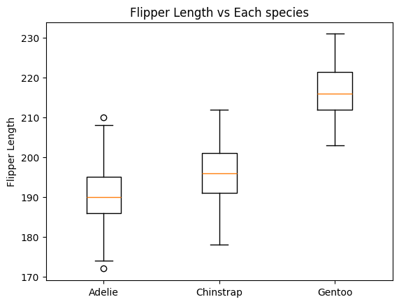

```python
plt.figure()
plt.boxplot(
    [
        df[df["species"]=="Adelie"]["flipper_length_mm"],
        df[df["species"]=="Chinstrap"]["flipper_length_mm"],
        df[df["species"]=="Gentoo"]["flipper_length_mm"]],
    tick_labels=["Adelie", "Chinstrap", "Gentoo"]
)
plt.ylabel("Flipper Length")
plt.title("Flipper Length vs Each species")
plt.show()
```

## Method

- Select one or more variables for analysis
- Plot the ECDF of the selected variable to examine its distribution and identify potential clusters in the data.
- Apply hierarchical clustering in order to identify natural clusters.
- Use the clusters from the dendrogram as bins.
- Build a species × bin contingency table. Rows = penguin species Columns = bins Entries = how many penguins of each species fall into each bin
- Divide each row entry by its corresponding row total in the contingency table to get the probability vector. Such probability vectors indicate how each species is allocated to bins and act as the observed (or alternative) multinomial probability vectors.
- Compute the pooled null vector p0 by adding the column totals across all species and dividing by the total sample size. This represents how all penguins fall across the bins if species labels are ignored.
- Two multinomial distributions can be defined for each species: Observed/alternative: Probability vector corresponding to the species row Null: Pooled null vector p0. The number of observations must equal the size of the species row.
- Simulate many multinomial samples under both the observed and null models, keeping the sample size fixed at that species’ row total.
- For each simulated sample, convert the count vector to proportions (a probability vector), then compute entropy.
- Plot and compare the entropy distribution of the observation with the entropy distribution of the null hypothesis. The more overlap there is, the weaker the feature, and the less overlap, the stronger the discrimination between the species.

### Separation Score

Although having the same number of clusters for each variable would make the separation scores easier to compare, in this analysis each variable was split according to its own natural tendency to form clusters. Some variables naturally split into more clusters than others. However, this does not make the separation score incorrect. Rather, it means that the score is based on the amount of species separation that can be identified from each variable’s natural clustering structure.

## ECDF and Histograms

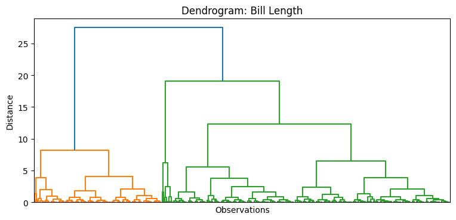

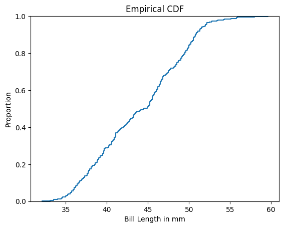

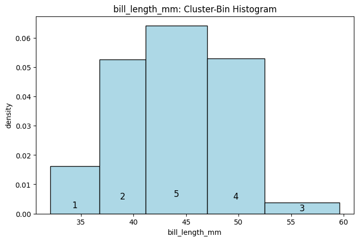

| bill_length_mm_cluster species | 1 | 2 | 3 | 4 | 5 |
| --- | --- | --- | --- | --- | --- |
| Adelie | 25 | 77 | 0 | 0 | 44 |
| Chinstrap | 0 | 0 | 4 | 39 | 25 |
| Gentoo | 0 | 0 | 5 | 58 | 56 |

```python
x = df[["bill_length_mm"]]

Z = linkage(x, method="complete", metric = "euclidean")

plt.figure(figsize=(9, 4))
dendrogram(Z, no_labels=True)
plt.title("Dendrogram: Bill Length")
plt.xlabel("Observations")
plt.ylabel("Distance")
plt.show()
label = fcluster(Z, t=7, criterion="distance")
df2 = df[["bill_length_mm", "species"]].copy()
df2["bill_length_mm_cluster"] = label
h1 = pd.crosstab(df2["species"], df2["bill_length_mm_cluster"])


plt.figure()
sns.ecdfplot(x = "bill_length_mm", data = df)
plt.xlabel("Bill Length in mm")
plt.title("Empirical CDF")
plt.show()


def cluster_bin_hist(dfin, value_col, cluster_col):
    d = dfin[[value_col, cluster_col]].dropna().copy()
    g = (d.groupby(cluster_col)[value_col].agg(center="median", count="size").sort_values("center"))
    centers = g["center"].to_numpy()
    mids = (centers[:-1] + centers[1:]) / 2
    left = np.r_[d[value_col].min(), mids]
    right = np.r_[mids, d[value_col].max()]
    g["left"] = left
    g["right"] = right
    g["width"] = g["right"] - g["left"]
    n = g["count"].sum()
    g["density"] = (g["count"] / n) / g["width"]
    plt.figure(figsize=(8,5))
    plt.bar(g["left"], g["density"], width=g["width"], align="edge", edgecolor="black", color = "LightBlue")
    for cid, r in g.iterrows():
        x = (r["left"] + r["right"]) / 2
        y = r["density"] * 0.08
        plt.text(x, y, str(cid), ha="center", va="bottom", fontsize=12)
    plt.xlabel(value_col)
    plt.ylabel("density")
    plt.title(f"{value_col}: Cluster-Bin Histogram")
    plt.show()
    return g

cluster_bin_hist(df2, "bill_length_mm", "bill_length_mm_cluster")
h1
```

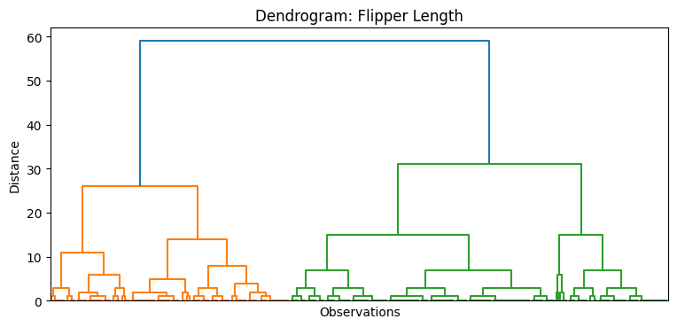

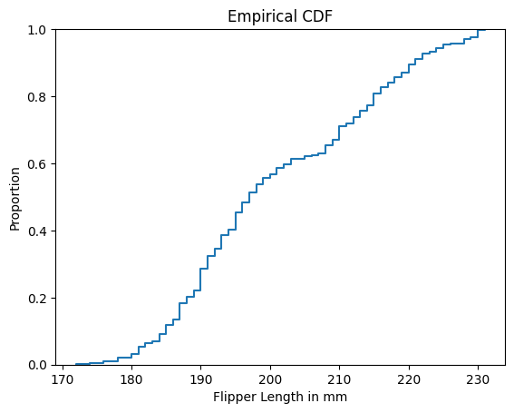

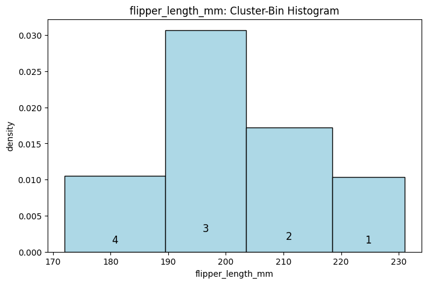

| flipper_length_mm_cluster | center | count | left | right | width | density |
| --- | --- | --- | --- | --- | --- | --- |
| 4 | 185.0 | 61 | 172.0 | 189.5 | 17.5 | 0.010468 |
| 3 | 194.0 | 143 | 189.5 | 203.5 | 14.0 | 0.030674 |
| 2 | 213.0 | 86 | 203.5 | 218.5 | 15.0 | 0.017217 |
| 1 | 224.0 | 43 | 218.5 | 231.0 | 12.5 | 0.010330 |

```python
x = df[["flipper_length_mm"]]

Z = linkage(x, method="complete", metric = "euclidean")

plt.figure(figsize=(9, 4))
dendrogram(Z, no_labels=True)
plt.title("Dendrogram: Flipper Length")
plt.xlabel("Observations")
plt.ylabel("Distance")
plt.show()
label = fcluster(Z, t=22, criterion="distance")
df3 = df[["flipper_length_mm", "species"]].copy()
df3["flipper_length_mm_cluster"] = label

h2 = pd.crosstab(df3["species"], df3["flipper_length_mm_cluster"])

plt.figure()
sns.ecdfplot(x = "flipper_length_mm", data = df)
plt.xlabel("Flipper Length in mm")
plt.title("Empirical CDF")
plt.show()
cluster_bin_hist(df3, "flipper_length_mm", "flipper_length_mm_cluster")
```

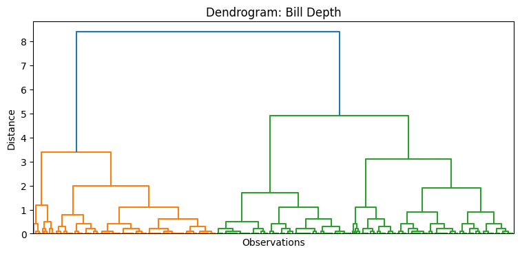

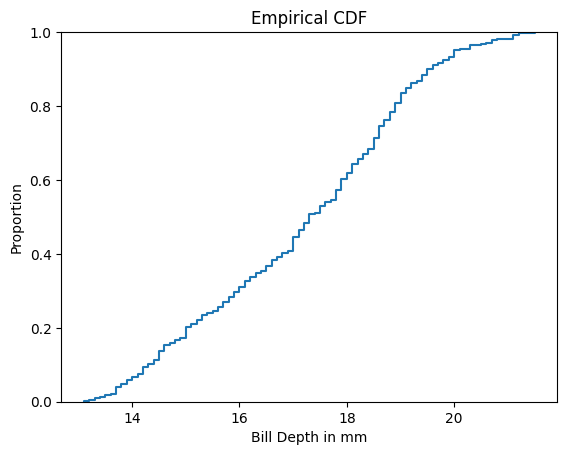

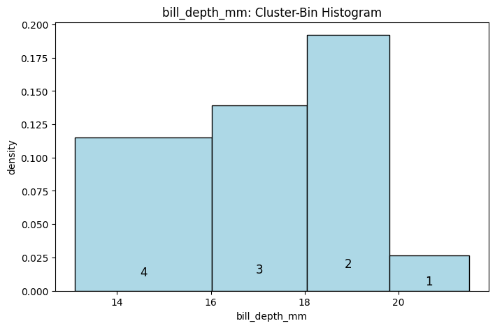

| bill_depth_mm_cluster | center | count | left | right | width | density |
| --- | --- | --- | --- | --- | --- | --- |
| 4 | 14.85 | 112 | 13.100 | 16.025 | 2.925 | 0.114987 |
| 3 | 17.20 | 94 | 16.025 | 18.050 | 2.025 | 0.139399 |
| 2 | 18.90 | 112 | 18.050 | 19.800 | 1.750 | 0.192192 |
| 1 | 20.70 | 15 | 19.800 | 21.500 | 1.700 | 0.026497 |

```python
x = df[["bill_depth_mm"]]

Z = linkage(x, method="complete", metric = "euclidean")

plt.figure(figsize=(9, 4))
dendrogram(Z, no_labels=True)
plt.title("Dendrogram: Bill Depth")
plt.xlabel("Observations")
plt.ylabel("Distance")
plt.show()
label = fcluster(Z, t=3.3, criterion="distance")
df4 = df[["bill_depth_mm", "species"]].copy()
df4["bill_depth_mm_cluster"] = label
h3 = pd.crosstab(df4["species"], df4["bill_depth_mm_cluster"])

plt.figure()
sns.ecdfplot(x = "bill_depth_mm", data = df)
plt.title("Empirical CDF")
plt.xlabel("Bill Depth in mm")
plt.show()
cluster_bin_hist(df4, "bill_depth_mm", "bill_depth_mm_cluster")
```

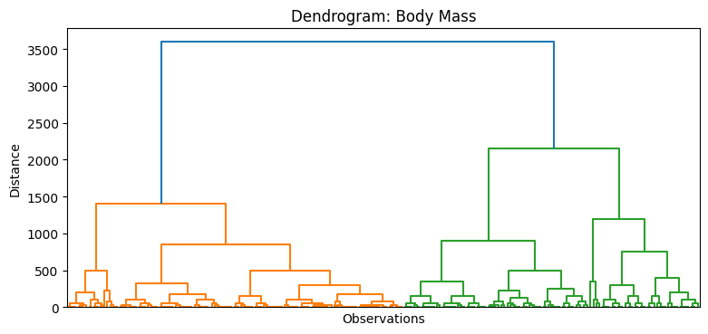

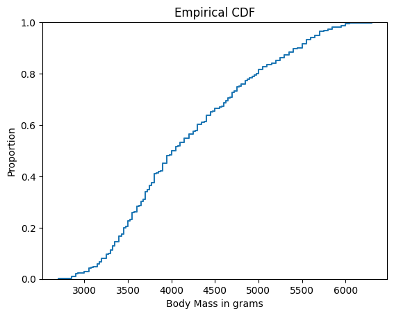

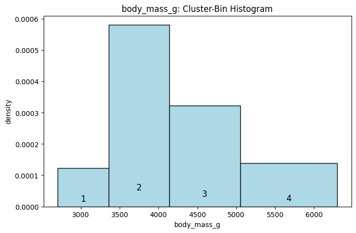

| body_mass_g_cluster | center | count | left | right | width | density |
| --- | --- | --- | --- | --- | --- | --- |
| 1 | 3050.0 | 27 | 2700.0 | 3362.5 | 662.5 | 0.000122 |
| 2 | 3675.0 | 150 | 3362.5 | 4137.5 | 775.0 | 0.000581 |
| 3 | 4600.0 | 98 | 4137.5 | 5050.0 | 912.5 | 0.000323 |
| 4 | 5500.0 | 58 | 5050.0 | 6300.0 | 1250.0 | 0.000139 |

```python
x = df[["body_mass_g"]]

Z = linkage(x, method="complete", metric = "euclidean")

plt.figure(figsize=(9, 4))
dendrogram(Z, no_labels=True)
plt.title("Dendrogram: Body Mass")
plt.xlabel("Observations")
plt.ylabel("Distance")
plt.show()
label = fcluster(Z, t=1200, criterion="distance")
df5 = df[["body_mass_g", "species"]].copy()
df5["body_mass_g_cluster"] = label
h4 = pd.crosstab(df5["species"], df5["body_mass_g_cluster"])

plt.figure()
sns.ecdfplot(df["body_mass_g"])
plt.xlabel("Body Mass in grams")
plt.title("Empirical CDF")
plt.show()
cluster_bin_hist(df5, "body_mass_g", "body_mass_g_cluster")
```

```python
display(h1, h2, h3, h4)
```

| bill_length_mm_cluster species | 1 | 2 | 3 | 4 | 5 |
| --- | --- | --- | --- | --- | --- |
| Adelie | 25 | 77 | 0 | 0 | 44 |
| Chinstrap | 0 | 0 | 4 | 39 | 25 |
| Gentoo | 0 | 0 | 5 | 58 | 56 |

| flipper_length_mm_cluster species | 1 | 2 | 3 | 4 |
| --- | --- | --- | --- | --- |
| Adelie | 0 | 3 | 92 | 51 |
| Chinstrap | 0 | 8 | 50 | 10 |
| Gentoo | 43 | 75 | 1 | 0 |

| bill_depth_mm_cluster species | 1 | 2 | 3 | 4 |
| --- | --- | --- | --- | --- |
| Adelie | 12 | 73 | 55 | 6 |
| Chinstrap | 3 | 39 | 26 | 0 |
| Gentoo | 0 | 0 | 13 | 106 |

| body_mass_g_cluster species | 1 | 2 | 3 | 4 |
| --- | --- | --- | --- | --- |
| Adelie | 24 | 93 | 29 | 0 |
| Chinstrap | 3 | 56 | 9 | 0 |
| Gentoo | 0 | 1 | 60 | 58 |

### Explanation

- For bill length, the histogram and contingency table show that the lower bill-length bins are mostly Adelie penguins. The middle bin is mixed across all three species, while the higher bill-length bins contain mostly Chinstrap and Gentoo. This suggests that bill length is helpful for identifying Adelie at the lower end of the scale, but it does not completely separate all three species on its own.
- Flipper length seems to be one of the best separating variables. The contingency table shows that the highest flipper length bins are mainly Gentoo, while the lower and middle bins are mostly Adelie and Chinstrap. So this variable is pretty useful for separating Gentoo from the others. There is still overlap between Adelie and Chinstrap in the middle bins, so the separation is not complete, but it still looks stronger then several of the other variables.
- Bill depth also seems to separate the species, but in a different way. The lowest bill depth bin is mostly Gentoo, while the middle bins are more mixed between Adelie and Chinstrap. So bill depth looks useful for separating Gentoo from the other two species, but it does not do as good of a job when it comes to Adelie and Chinstrap. In general, bill depth still seems to carry useful species information, but it is not equally strong for all three species.
- Body mass also looks like a useful variable for separating species. The highest body mass bins are mostly Gentoo, while the lower bins are mainly Adelie and Chinstrap. This means body mass is also pretty good for separating Gentoo from the other species. However, Adelie and Chinstrap overlap a lot in the lower and middle body mass bins, so body mass by itself is not enough to clearly separate all three species. Still, it seems to be a strong variable when it comes to identifying Gentoo.

## Bill Length analysis

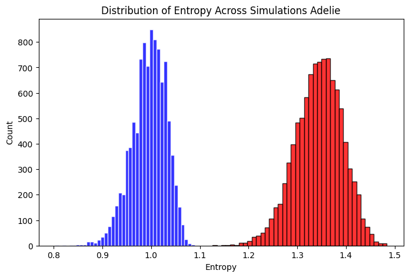

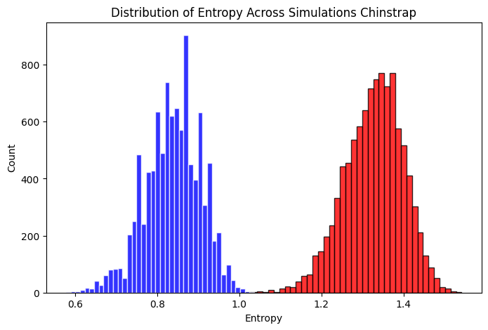

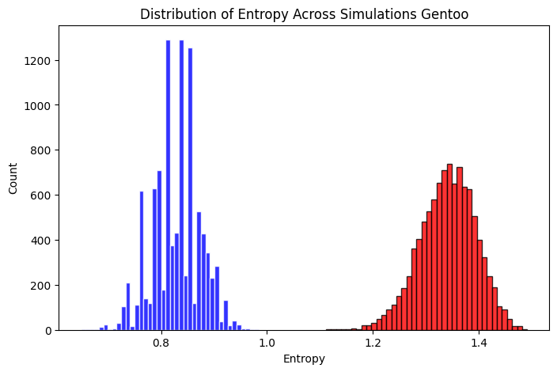

| bill_length_mm_cluster species | 1 | 2 | 3 | 4 | 5 |
| --- | --- | --- | --- | --- | --- |
| Adelie | 25 | 77 | 0 | 0 | 44 |
| Chinstrap | 0 | 0 | 4 | 39 | 25 |
| Gentoo | 0 | 0 | 5 | 58 | 56 |

```python
np.random.seed(1)

def sim_entropy(n, probs, n_sim=10000):
    z = np.random.multinomial(n, probs, size=n_sim)
    ent = []
    for row in z:
        p = row / row.sum()
        h = -np.sum(p[p > 0] * np.log(p[p > 0]))
        ent.append(h)
    return np.array(ent)


vector_p0 = (h1.sum(axis=0) / h1.values.sum()).to_list()


for species in h1.index:
    row = h1.loc[species, :]
    n_species = int(row.sum())
    p_species = (row / n_species).to_list()

    ent_null = sim_entropy(n_species, vector_p0)
    ent_species = sim_entropy(n_species, p_species)

    plt.figure(figsize=(8,5))
    plt.hist(ent_null, bins=40, edgecolor="black", alpha=0.8, color="red")
    plt.hist(ent_species, bins=40, edgecolor="white", alpha=0.8, color="blue")
    plt.xlabel("Entropy")
    plt.ylabel("Count")
    plt.title(f"Distribution of Entropy Across Simulations {species}")
    plt.show()
h1
```

From the graphs above, we can see that the observed entropy distributions for all three species are clearly separated from the null entropy distributions. This suggests that bill length carries useful information for distinguishing species. Across the 10,000 simulated observations, the observed entropies are much lower than the null entropies, which means the species are distributed across the bill-length bins in a more structured way than we would expect by chance. Therefore, bill length appears to be a useful variable for separating penguin species.

## Flipper Length Analysis

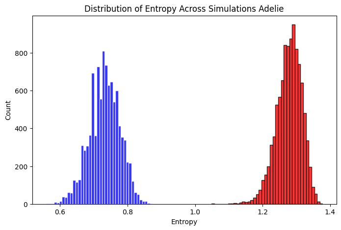

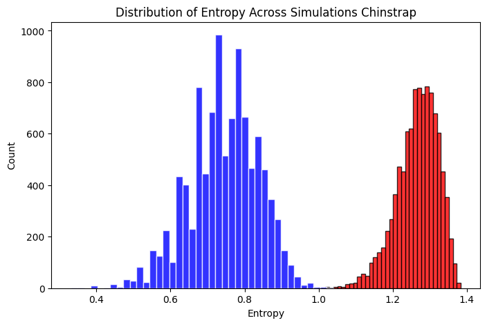

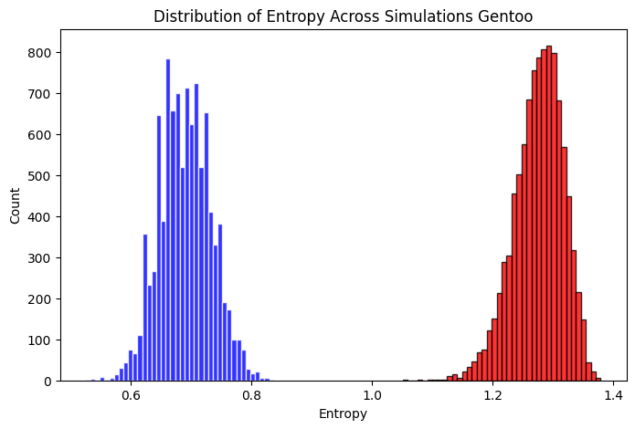

| flipper_length_mm_cluster species | 1 | 2 | 3 | 4 |
| --- | --- | --- | --- | --- |
| Adelie | 0 | 3 | 92 | 51 |
| Chinstrap | 0 | 8 | 50 | 10 |
| Gentoo | 43 | 75 | 1 | 0 |

```python
np.random.seed(1)

vector_p0 = (h2.sum(axis=0) / h2.values.sum()).to_list()

# species-specific plots (Adelie, Chinstrap, Gentoo)
for species in h2.index:
    row = h2.loc[species, :]
    n_species = int(row.sum())
    p_species = (row / n_species).to_list()

    ent_null = sim_entropy(n_species, vector_p0)
    ent_species = sim_entropy(n_species, p_species)

    plt.figure(figsize=(8,5))
    plt.hist(ent_null, bins=40, edgecolor="black", alpha=0.8, color="red")
    plt.hist(ent_species, bins=40, edgecolor="white", alpha=0.8, color="blue")
    plt.xlabel("Entropy")
    plt.ylabel("Count")
    plt.title(f"Distribution of Entropy Across Simulations {species}")
    plt.show()
h2
```

By looking at the flipper length patterns, we can see that the distribution of Adelie, Chinstrap, and Gentoo penguins is not random. The observed entropy distributions for all three species are clearly different from the null entropy distribution, which suggests that flipper length carries useful information for separating species. The observed entropy values are centered around about 0.7 to 0.8, while the null entropy values are centered much higher, around 1.3. This large difference indicates that flipper length is a useful variable for distinguishing species.

From the contingency table, most Gentoo penguins fall into the first two flipper-length bins, while most Adelie penguins fall into the last two bins. This means flipper length is especially useful for separating Gentoo from Adelie. Chinstrap penguins are mostly concentrated in the middle bins, so they are also different, but their separation is not as clear as it is for Gentoo and Adelie. Overall, flipper length can be considered a strong variable for distinguishing penguin species.

## Bill Depth Analysis

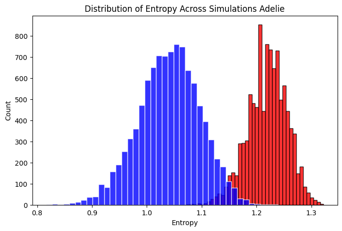

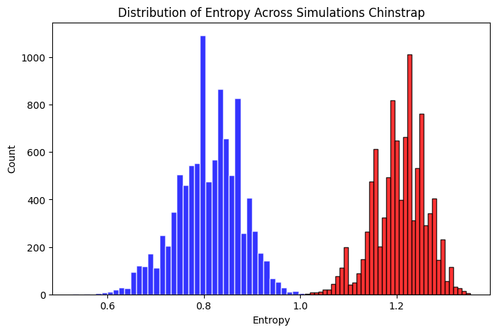

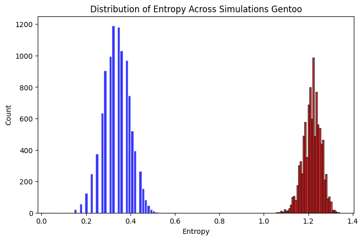

| bill_depth_mm_cluster species | 1 | 2 | 3 | 4 |
| --- | --- | --- | --- | --- |
| Adelie | 12 | 73 | 55 | 6 |
| Chinstrap | 3 | 39 | 26 | 0 |
| Gentoo | 0 | 0 | 13 | 106 |

```python
np.random.seed(1)

vector_p0 = (h3.sum(axis=0) / h3.values.sum()).to_list()

# species-specific plots (Adelie, Chinstrap, Gentoo)
for species in h3.index:
    row = h3.loc[species, :]
    n_species = int(row.sum())
    p_species = (row / n_species).to_list()

    ent_null = sim_entropy(n_species, vector_p0)
    ent_species = sim_entropy(n_species, p_species)

    plt.figure(figsize=(8,5))
    plt.hist(ent_null, bins=40, edgecolor="black", alpha=0.8, color="red")
    plt.hist(ent_species, bins=40, edgecolor="white", alpha=0.8, color="blue")
    plt.xlabel("Entropy")
    plt.ylabel("Count")
    plt.title(f"Distribution of Entropy Across Simulations {species}")
    plt.show()
h3
```

When looking at the entropy values for bill depth, the observed values are lower than the null values for all three species. This means that the species do not fall randomly into the bill-depth categories, and that bill depth does carry useful information for distinguishing species. The separation appears strongest for Gentoo, since its observed entropy values are much lower than the null values and there is almost no overlap. Chinstrap also shows a clear difference from the null, although it is less extreme than Gentoo. The separation for Adelie is weaker, since there is still some overlap with the null values.

Overall, bill depth seems especially useful for distinguishing Gentoo from the other two species. On the other hand, it appears weaker for distinguishing Adelie from Chinstrap, since those two species overlap much more in the middle bill-depth categories.

## Body Mass Analysis

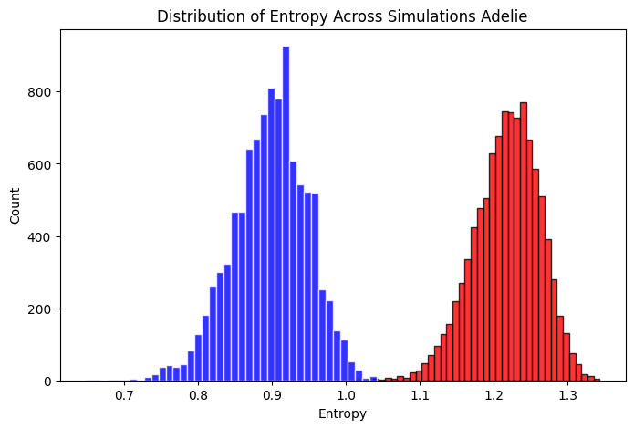

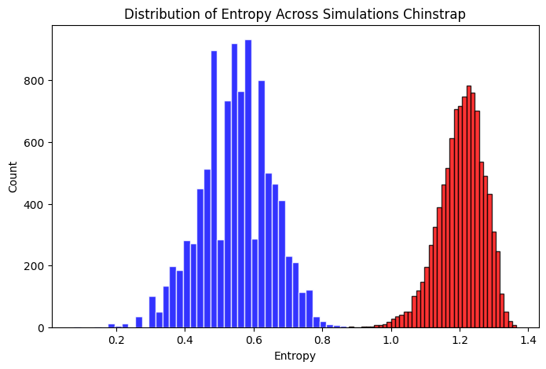

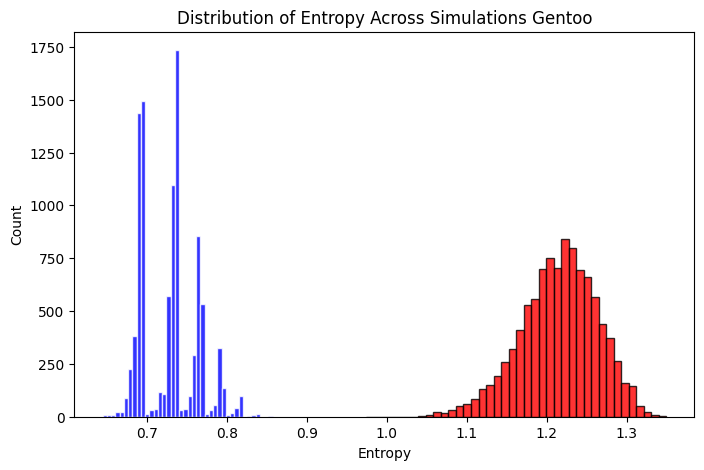

| body_mass_g_cluster species | 1 | 2 | 3 | 4 |
| --- | --- | --- | --- | --- |
| Adelie | 24 | 93 | 29 | 0 |
| Chinstrap | 3 | 56 | 9 | 0 |
| Gentoo | 0 | 1 | 60 | 58 |

```python
np.random.seed(1)

p_null = (h4.sum(axis=0) / h4.values.sum()).to_numpy()

for sp in ["Adelie", "Chinstrap", "Gentoo"]:
    row = h4.loc[sp].to_numpy()
    n_sp = int(row.sum())
    p_sp = row / n_sp

    ent_null = sim_entropy(n_sp, p_null)
    ent_sp = sim_entropy(n_sp, p_sp)

    plt.figure(figsize=(8,5))
    plt.hist(ent_null, bins=40, edgecolor="black", alpha=0.8, color="red")
    plt.hist(ent_sp, bins=40, edgecolor="white", alpha=0.8, color="blue")
    plt.xlabel("Entropy")
    plt.ylabel("Count")
    plt.title(f"Distribution of Entropy Across Simulations {sp}")
    plt.show()
h4
```

From the contingency table, Gentoo is mostly concentrated in the higher body-mass bins, while Adelie and Chinstrap are mostly found in the lower and middle bins. This means body mass is especially useful for separating Gentoo from the other two species. However, Adelie and Chinstrap still overlap quite a lot in the lower and middle body-mass groups, so body mass is weaker for distinguishing those two species from each other. Overall, body mass seems to be a useful variable, but its separating power is strongest for Gentoo.

## Island Analysis

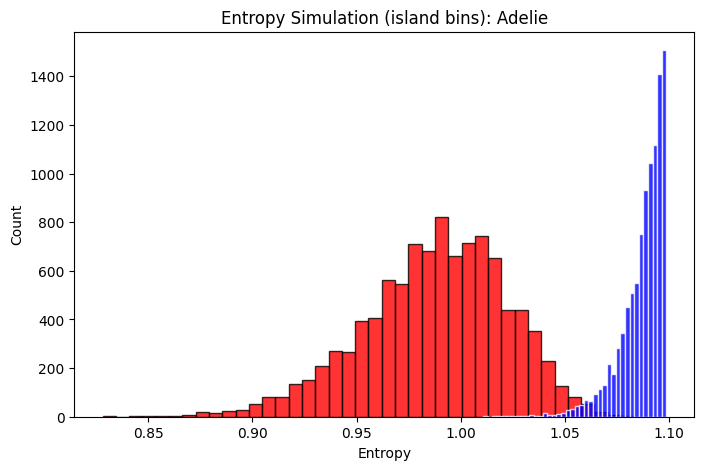

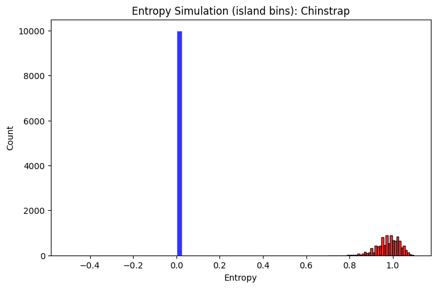

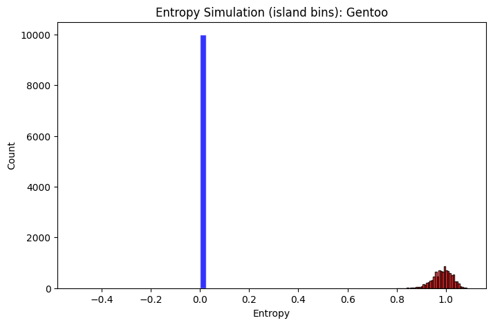

| island species | Biscoe | Dream | Torgersen |
| --- | --- | --- | --- |
| Adelie | 44 | 55 | 47 |
| Chinstrap | 0 | 68 | 0 |
| Gentoo | 119 | 0 | 0 |

```python
np.random.seed(1)

# 1) Contingency table for island
h_island = pd.crosstab(df["species"], df["island"])

p_null = (h_island.sum(axis=0) / h_island.values.sum()).to_numpy()

for sp in h_island.index:
    row = h_island.loc[sp].to_numpy()
    n_sp = int(row.sum())
    p_obs = row / n_sp

    ent_null = sim_entropy(n_sp, p_null)
    ent_obs = sim_entropy(n_sp, p_obs)

    mu_obs = ent_obs.mean()
    mu_null = ent_null.mean()
    sd_obs = ent_obs.std(ddof=1)
    sd_null = ent_null.std(ddof=1)

    gap = mu_null - mu_obs
    d = gap / np.sqrt((sd_obs**2 + sd_null**2) / 2)

    plt.figure(figsize=(8,5))
    plt.hist(ent_null, bins=40, edgecolor="black", alpha=0.8, color="red")
    plt.hist(ent_obs, bins=40, edgecolor="white", alpha=0.8, color="blue")
    plt.xlabel("Entropy")
    plt.ylabel("Count")
    plt.title(f"Entropy Simulation (island bins): {sp}")
    plt.show()
h_island
```

In the entropy graphs, it can be observed that the variable “island” behaves very differently depending on the penguin species. Since the entropy values for both Chinstrap and Gentoo are nearly zero, this indicates that each of these two species is found on only one island. On the other hand, Adelie is observed on all three islands, so its entropy is much higher and close to the maximum possible value for three groups. Thus, the variable “island” is highly discriminative for Chinstrap and Gentoo penguins, but less informative for Adelie.

## Pair Plot Analysis

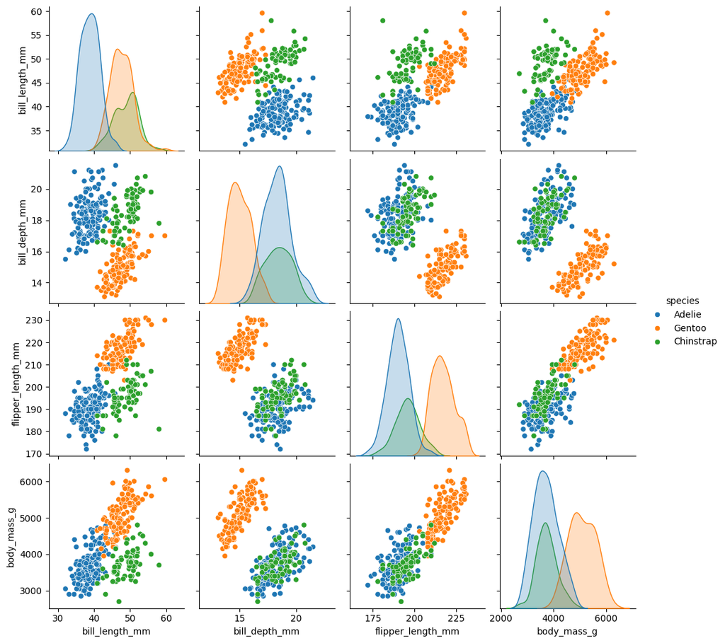

```python
cols = ["bill_length_mm", "bill_depth_mm", "flipper_length_mm", "body_mass_g"]

sns.pairplot(
    df.dropna(subset=cols + ["species"]),
    vars=cols,
    hue="species",
    diag_kind="kde"
)
plt.show()
```

The pair plot technique was adopted as a method of determining whether variable pairs could help separate the species better than individual variables. This method does not equate to the one-dimensional entropy approach; however, it helps to provide additional visual proof as far as the usefulness of specific variable pairs goes.

The pair plot indicates that bill depth-body mass, bill depth-flipper length, and flipper length-body mass are highly effective variables in the separation between Gentoo and the remaining two penguins. These three combinations show a large separation between Gentoo and the other two species where Gentoo lies farther apart, while the other two species are very close to each other. On the contrary, bill length-body mass, bill length-flipper length, and bill length-bill depth combinations are more efficient when distinguishing between all the three penguins together. Even though there is overlap, all the three species become somewhat distinctive. The conclusion from the pair plot is that some variable combinations are effective in separating only Gentoo penguins, while others work well in separating all three species together.